# BMIN503/EPID600 Final Project - Exploratory analysis of vaccination coverage and worldwide incidence of infectious diseases

```r
# Measles
max_incidence <- max(max(na.omit(world_incidence_measles$X2014)), max(na.omit(world_incidence_measles$X2015)), max(na.omit(world_incidence_measles$X2016)), max(na.omit(world_incidence_measles$X2017)), max(na.omit(world_incidence_measles$X2018)))

mean_incidence <- mean(mean(na.omit(world_incidence_measles$X2014)), mean(na.omit(world_incidence_measles$X2015)), mean(na.omit(world_incidence_measles$X2016)), mean(na.omit(world_incidence_measles$X2017)), mean(na.omit(world_incidence_measles$X2018)))

sd_incidence <- sd(c(na.omit(world_incidence_measles$X2014), na.omit(world_incidence_measles$X2015), na.omit(world_incidence_measles$X2016), na.omit(world_incidence_measles$X2017), na.omit(world_incidence_measles$X2018)))

for (year in c("X2014", "X2015", "X2016", "X2017", "X2018")) {
  print(
    tm_shape(world_incidence_measles) +
    tm_polygons(year, title = paste(str_remove(year, "X"), "Measles Incidence"),
              # showNA = FALSE,
              border.col = "black", border.alpha = .5,
              style = "fixed",
              breaks = c(0, sd_incidence, 2*sd_incidence, 3*sd_incidence, max_incidence),
              palette = "YlOrRd")
  )
}
```

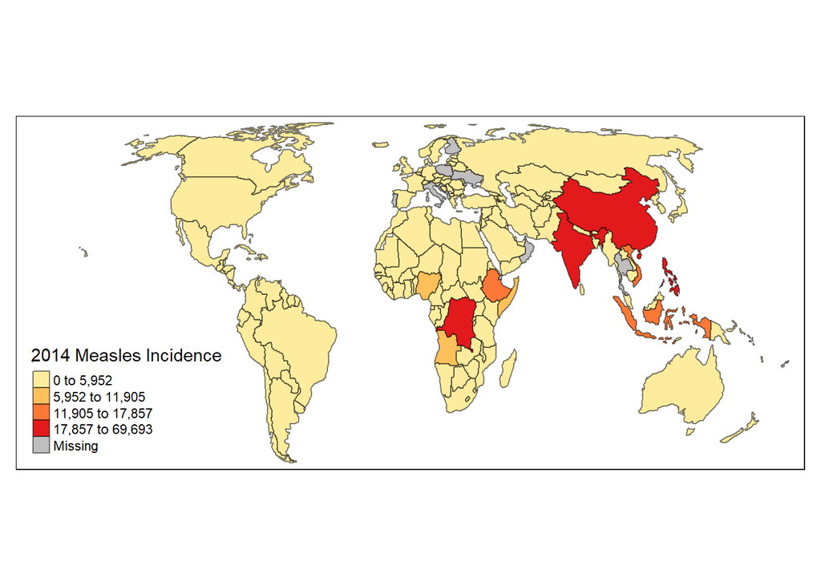

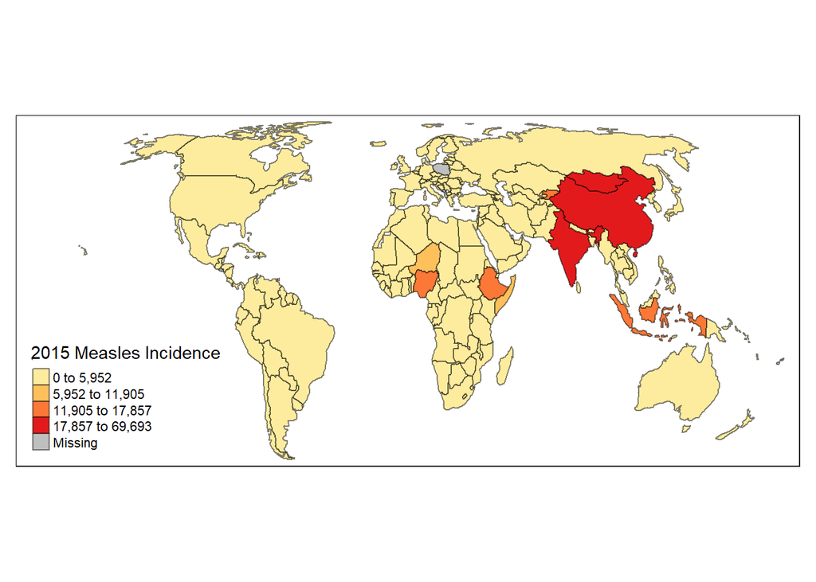

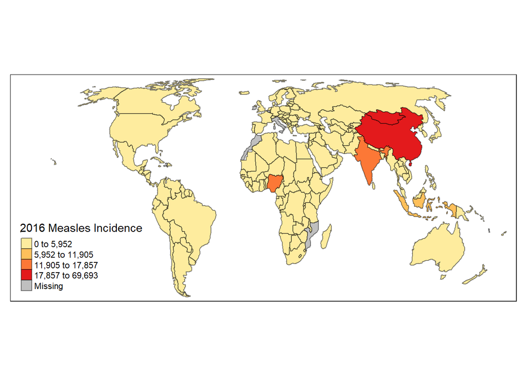

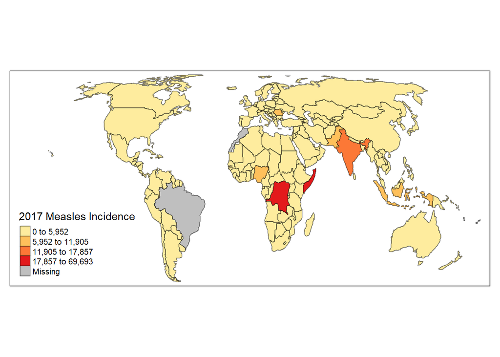

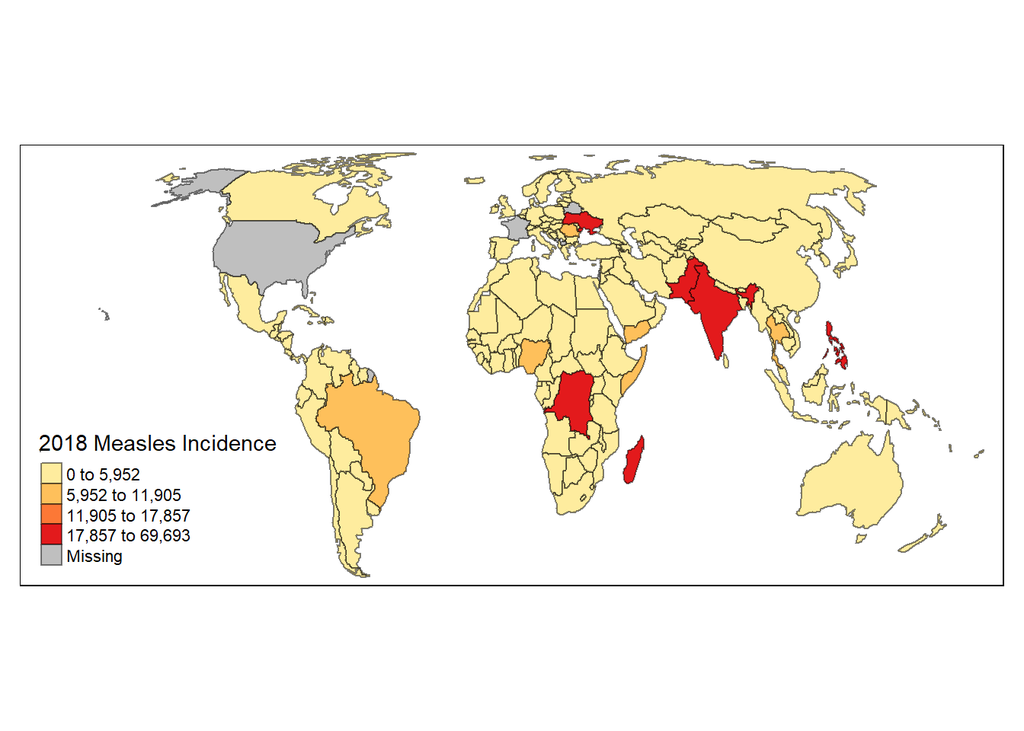

```r
# Polio
max_incidence <- max(max(na.omit(world_incidence_polio$X2014)), max(na.omit(world_incidence_polio$X2015)), max(na.omit(world_incidence_polio$X2016)), max(na.omit(world_incidence_polio$X2017)), max(na.omit(world_incidence_polio$X2018)))

mean_incidence <- mean(mean(na.omit(world_incidence_polio$X2014)), mean(na.omit(world_incidence_polio$X2015)), mean(na.omit(world_incidence_polio$X2016)), mean(na.omit(world_incidence_polio$X2017)), mean(na.omit(world_incidence_polio$X2018)))

sd_incidence <- sd(c(na.omit(world_incidence_polio$X2014), na.omit(world_incidence_polio$X2015), na.omit(world_incidence_polio$X2016), na.omit(world_incidence_polio$X2017), na.omit(world_incidence_polio$X2018)))

for (year in c("X2014", "X2015", "X2016", "X2017", "X2018")) {
  print(
    tm_shape(world_incidence_polio) +
    tm_polygons(year, title = paste(str_remove(year, "X"), "Polio Incidence"),
              # showNA = FALSE,
              border.col = "black", border.alpha = .5,
              style = "fixed",
              breaks = c(0, sd_incidence, 2*sd_incidence, 3*sd_incidence, max_incidence),
              palette = "YlOrRd")
  )
}
```

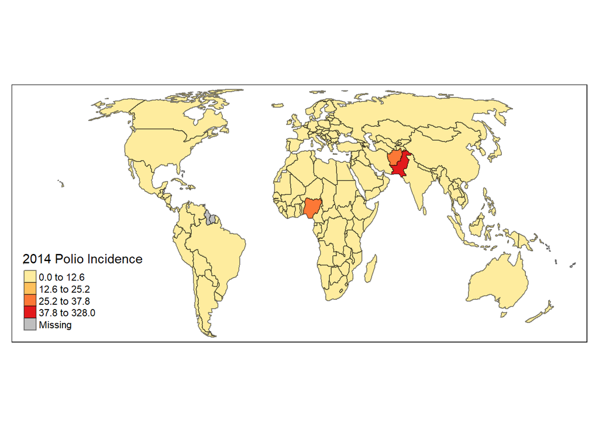

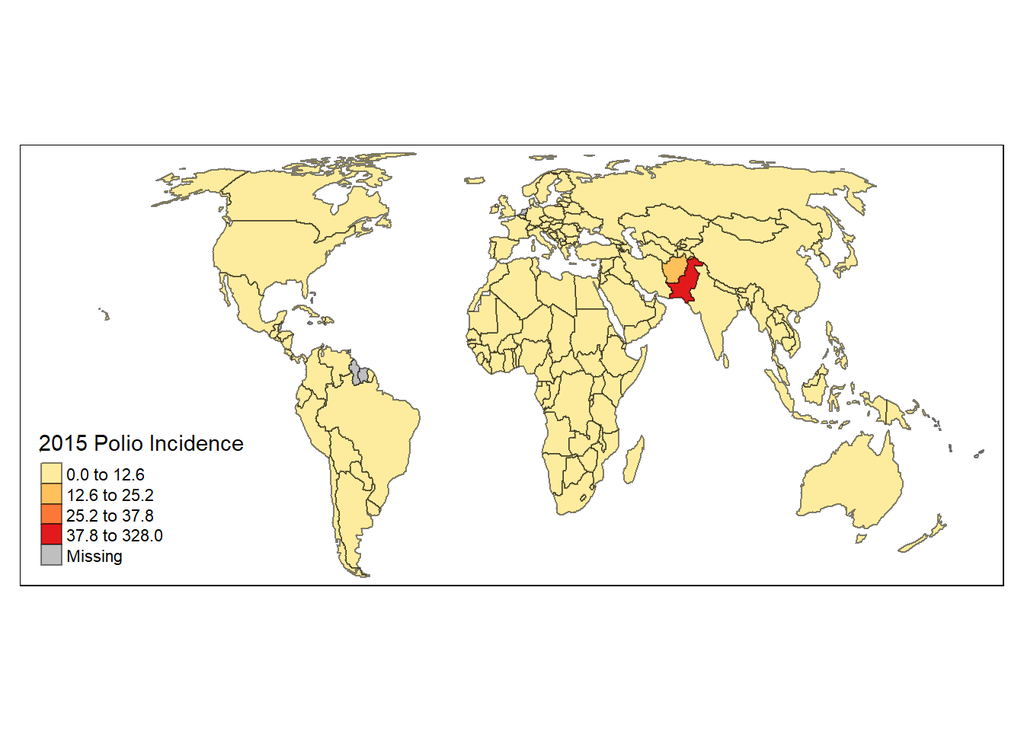

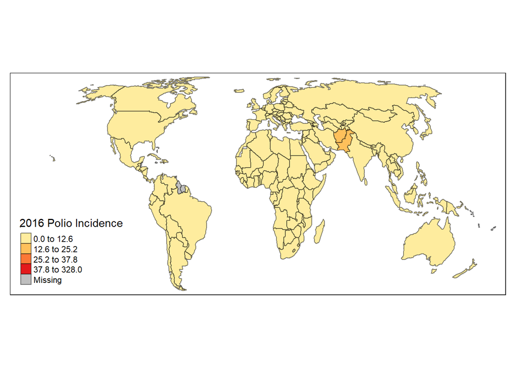

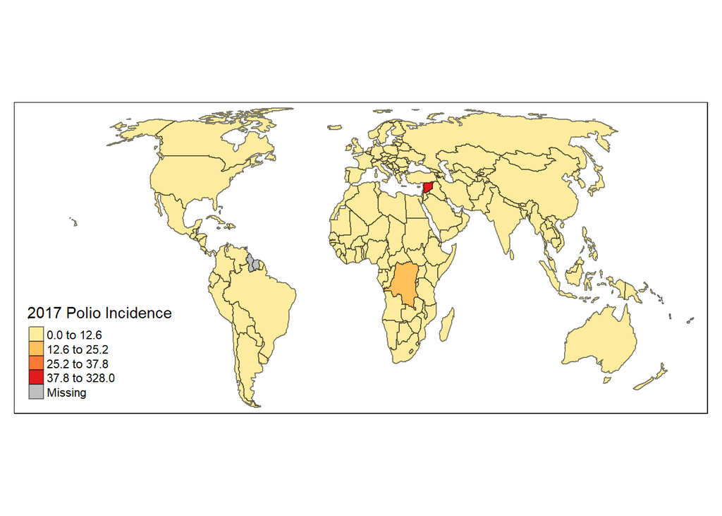

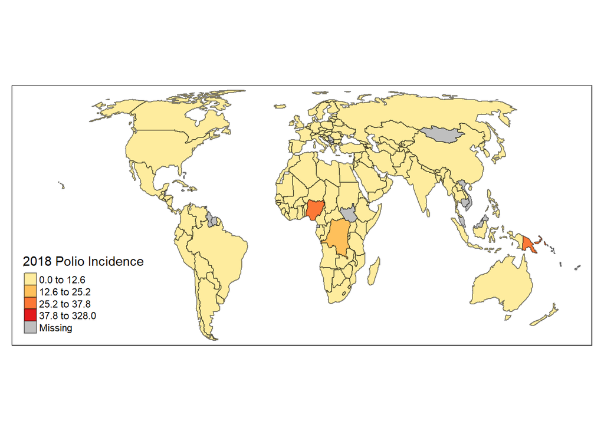

Below is a section for outdated code.

```r
# Outdated Code

# # Filter by region choosing diseases of interest
# AFR_incidence <- filter(regional_global_incidence, region == "AFR", Disease %in% c("diphtheria", "pertussis", "measles", "polio", "rubella"))
# AMR_incidence <- filter(regional_global_incidence, region == "AMR", Disease %in% c("diphtheria", "pertussis", "measles", "polio", "rubella"))
# EMR_incidence <- filter(regional_global_incidence, region == "EMR", Disease %in% c("diphtheria", "pertussis", "measles", "polio", "rubella"))
# EUR_incidence <- filter(regional_global_incidence, region == "EUR", Disease %in% c("diphtheria", "pertussis", "measles", "polio", "rubella"))
# SEAR_incidence <- filter(regional_global_incidence, region == "SEAR", Disease %in% c("diphtheria", "pertussis", "measles", "polio", "rubella"))
# WPR_incidence <- filter(regional_global_incidence, region == "WPR", Disease %in% c("diphtheria", "pertussis", "measles", "polio", "rubella"))
#
# # Reshape dataframes
# AFR_incidence <- melt(AFR_incidence)
# AMR_incidence <- melt(AMR_incidence)
# EMR_incidence <- melt(EMR_incidence)
# EUR_incidence <- melt(EUR_incidence)
# SEAR_incidence <- melt(SEAR_incidence)
# WPR_incidence <- melt(WPR_incidence)
#
# # Covert x-axis factor to numeric
# AFR_incidence$variable <- as.numeric(as.character(AFR_incidence$variable))
# AMR_incidence$variable <- as.numeric(as.character(AMR_incidence$variable))
# EMR_incidence$variable <- as.numeric(as.character(EMR_incidence$variable))
# EUR_incidence$variable <- as.numeric(as.character(EUR_incidence$variable))
# SEAR_incidence$variable <- as.numeric(as.character(SEAR_incidence$variable))
# WPR_incidence$variable <- as.numeric(as.character(WPR_incidence$variable))
#
# for (disease in unique(AMR_incidence$Disease)) {
#     print(
#       ggplot(AMR_incidence[AMR_incidence$Disease == disease,], aes(variable, value)) +
#         geom_point() +
#         geom_line() +
#         ggtitle(paste("AMR region incidence of", disease)) +
#         xlab("Year") +
#         ylab("Incidence")
#     )
# }
#
# # DTP3 coverage per country over time
# for (country in levels(DTP3_coverage$Cname)) {
#   cur <- filter(DTP3_coverage, Cname == country)
#   if (is_empty(cur$Year)) {
#     next
#   }
#   # Plots of reported coverage by country over time
#   print(
#     ggplot(cur, aes(Year, Percent_coverage)) +
#       geom_line(size = 1, linetype = 2) +
#       geom_point(shape = 4, size = 2) +
#       scale_color_manual(values = c("black", "gray40")) +
#       theme_bw() +
#       # geom_smooth() +
#       ggtitle(wrapper(paste("Reported coverage of DTP3 from ", min(cur$Year), "to ", max(cur$Year), "in ", country), width = 35)) +
#     theme(plot.title = element_text(hjust = 0),
#           axis.text.x = element_text(angle = -90, hjust = 0, vjust = 0))
#   )
# }
#
# # MCV1 coverage per country over time
# for (country in levels(MCV1_coverage$Cname)) {
#   cur <- filter(MCV1_coverage, Cname == country)
#   if (is_empty(cur$Year)) {
#     next
#   }
#   # Plots of reported coverage by country over time
#   print(
#     ggplot(cur, aes(Year, Percent_coverage)) +
#       geom_line(size = 1, linetype = 2) +
#       geom_point(shape = 4, size = 2) +
#       scale_color_manual(values = c("black", "gray40")) +
#       theme_bw() +
#       # geom_smooth() +
#       ggtitle(wrapper(paste("Reported coverage of MCV1 from ", min(cur$Year), "to ", max(cur$Year), "in ", country), width = 35)) +
#     theme(plot.title = element_text(hjust = 0),
#           axis.text.x = element_text(angle = -90, hjust = 0, vjust = 0))
#   )
# }
#
#
# # Pol3 coverage per country over time
# for (country in levels(Pol3_coverage$Cname)) {
#   cur <- filter(Pol3_coverage, Cname == country)
#   if (is_empty(cur$Year)) {
#     next
#   }
#   # Plots of reported coverage by country over time
#   print(
#     ggplot(cur, aes(Year, Percent_coverage)) +
#       geom_line(size = 1, linetype = 2) +
#       geom_point(shape = 4, size = 2) +
#       scale_color_manual(values = c("black", "gray40")) +
#       theme_bw() +
#       # geom_smooth() +
#       ggtitle(wrapper(paste("Reported coverage of Pol3 from ", min(cur$Year), "to ", max(cur$Year), "in ", country), width = 35)) +
#     theme(plot.title = element_text(hjust = 0),
#           axis.text.x = element_text(angle = -90, hjust = 0, vjust = 0))
#   )
# }
#
# # RCV1 coverage per country over time
# for (country in levels(RCV1_coverage$Cname)) {
#   cur <- filter(RCV1_coverage, Cname == country)
#   if (is_empty(cur$Year)) {
#     next
#   }
#   # Plots of reported coverage by country over time
#   print(
#     ggplot(cur, aes(Year, Percent_coverage)) +
#       geom_line(size = 1, linetype = 2) +
#       geom_point(shape = 4, size = 2) +
#       scale_color_manual(values = c("black", "gray40")) +
#       theme_bw() +
#       # geom_smooth() +
#       ggtitle(wrapper(paste("Reported coverage of RCV1 from ", min(cur$Year), "to ", max(cur$Year), "in ", country), width = 35)) +
#     theme(plot.title = element_text(hjust = 0),
#           axis.text.x = element_text(angle = -90, hjust = 0, vjust = 0))
#   )
# }
```

### Conclusion

Overall, I performed an exploratory descriptive analysis about recent trends in the reported cases of several diseases, as well as rates of vaccine coverage on a per country basis. Recent years have observed a decrease in the number of countries at sufficient vaccine threshold coverage necessary for herd immunity for several diseases. In particular, parts of the Americas (usually South), Africa, and South East Asia lack sufficient vaccination for herd immunity, for various diseases and as a result may be prone to disease persistance and increasing rates of reported cases in the future. Polio still exists and measles is still a significant issue in other countries. Notably, the U.S. is observing increasing cases of pertussis, which may be significant as a very well-developed country. It would be interesting to perform this analysis with low or high incidence or reported cases as an outcome with country status (developing, developed, etc.) as a predictor, along with other factors such as total population, GDP, proximity to other countries (# of neighboring countries), whether it is landlocked or not, etc. All of these factors may play a role in the spread of disease and may be correlated to recent trends in the analyzed infectious diseases. Finally, it is important to not that these problems are not always due to inadequate vaccination coverage, and that having sufficient vaccination coverage is not an immediate indicator of disease elimination. Achieving and MAINTAINING herd immunity over time is essential to reducing disease burden because elimination of disease persistence takes place over time.